# Análise Exploratória de Dados

UFCG - Doutorado em Ciência da Computação / Disciplina: FPCC II / Aluno: Jean Barros

## Sobre os dados

Os dados utilizados são da base de dados IMDb (Internet Move Database) é uma das maiores base de dados online sobre cinema e tudo o que envolve a indústria do entretenimento. Além de reunir informações sobre artistas e produções, o site também permite que usuários criem listas e avaliem seus filmes favoritos. Link da base: https://www.imdb.com/interfaces/

##### **Amostra dos dados:**

```
Rows: 85,855
Columns: 16
$ imdb_title_id            <chr> "tt0000009", "tt0000574", "tt0001892", "tt0002101", "tt0002130", "tt0002199", "tt0002423", "tt0002445", "tt00~
$ title                    <chr> "Miss Jerry", "The Story of the Kelly Gang", "Den sorte drøm", "Cleopatra", "L'Inferno", "From the Manger to ~
$ year                     <int> 1894, 1906, 1911, 1912, 1911, 1912, 1919, 1913, 1912, 1912, 1913, 1913, 1913, 1913, 1914, 1914, 1913, 1914, 1~
$ duration                 <int> 45, 70, 53, 100, 68, 60, 85, 120, 120, 55, 121, 54, 96, 61, 90, 50, 90, 55, 85, 88, 88, 72, 78, 70, 148, 52, ~
$ reviews_from_users       <dbl> 1, 7, 5, 25, 31, 13, 12, 7, 4, 8, 9, 9, 16, 8, NA, 2, 6, 6, 20, 14, 13, 7, 14, 8, 31, 10, 7, 5, 6, 5, 7, 11, ~
$ reviews_from_critics     <dbl> 2, 7, 2, 3, 14, 5, 9, 5, 1, 1, 9, 28, 7, 23, 4, 2, 18, NA, 26, 11, 7, 2, 11, 3, 26, 3, 4, 18, 3, NA, 4, 7, 9,~
$ total_votes              <dbl> 154, 589, 188, 446, 2237, 484, 753, 273, 198, 225, 331, 1944, 948, 1349, 100, 124, 1050, 187, 1768, 552, 474,~
$ males_allages_avg_vote   <dbl> 6.2, 6.1, 5.9, 5.1, 7.0, 5.7, 6.6, 6.2, 6.7, 5.5, 6.5, 6.9, 7.0, 6.9, 6.1, 6.6, 6.9, 5.7, 6.5, 5.9, 6.1, 6.4,~
$ males_allages_votes      <dbl> 97, 425, 146, 299, 1607, 354, 530, 191, 153, 168, 232, 1441, 676, 998, 75, 88, 787, 124, 1230, 399, 329, 252,~
$ females_allages_avg_vote <dbl> 6.0, 6.2, 5.7, 5.9, 7.2, 5.8, 7.4, 6.3, 7.0, 7.7, 7.1, 7.4, 7.4, 7.2, 6.3, 6.4, 7.5, 6.4, 6.7, 6.5, 6.2, 6.9,~
$ females_allages_votes    <dbl> 35, 50, 15, 39, 215, 31, 93, 21, 19, 15, 34, 233, 107, 161, 3, 11, 124, 16, 224, 54, 43, 53, 264, 10, 402, 31~
$ us_voters_rating         <dbl> 6.4, 6.0, 6.2, 5.5, 7.0, 5.9, 6.6, 5.8, 6.7, 5.8, 6.9, 7.0, 7.1, 7.0, 6.9, 6.1, 6.8, 5.4, 6.3, 6.1, 6.2, 6.5,~
$ us_voters_votes          <dbl> 51, 96, 31, 207, 488, 173, 139, 40, 25, 109, 67, 567, 212, 397, 11, 10, 310, 52, 350, 251, 156, 74, 589, 51, ~
$ non_us_voters_rating     <dbl> 6.0, 6.2, 5.9, 4.7, 7.0, 5.6, 6.8, 6.2, 6.8, 5.4, 6.5, 6.9, 7.0, 6.9, 6.1, 6.6, 7.0, 5.9, 6.5, 6.0, 6.1, 6.4,~
$ non_us_voters_votes      <dbl> 70, 331, 123, 105, 1166, 181, 455, 154, 135, 68, 182, 1024, 519, 718, 65, 83, 570, 77, 978, 184, 197, 213, 34~
$ weighted_average_vote    <dbl> 5.9, 6.1, 5.8, 5.2, 7.0, 5.7, 6.8, 6.2, 6.7, 5.5, 6.6, 7.0, 7.1, 7.0, 6.2, 6.5, 7.0, 5.8, 6.5, 6.0, 6.2, 6.4,~
```

##### **Dicionário dos dados:**

Para uma melhor compreensão, na Tabela abaixo temos o dicionário de dados da base utilizada no experimento.

```
   VARIÁVEL                 TIPO      DESCRIÇÃO
$ imdb_title_id            <chr> ID do título no IMDb
$ year                     <int> Ano de lançamento
$ duration                 <int> Duração
$ reviews_from_users       <dbl> Número de comentários de usuários
$ reviews_from_critics     <dbl> Número de comentários dos críticos
$ total_votes              <dbl> Total de votos recebidos
$ males_allages_avg_vote   <dbl> Classificação média de todos os usuários do sexo masculino (todas as idades)
$ males_allages_votes      <dbl> Número de votos de todos os usuários do sexo masculino (todas as idades)
$ females_allages_avg_vote <dbl> Classificação média de todos os usuários do sexo feminino (todas as idades)
$ females_allages_votes    <dbl> Número de votos de todos os usuários do sexo feminino (todas as idades)
$ us_voters_rating         <dbl> Classificação média de usuários americanos
$ us_voters_votes          <dbl> Número de votos de usuários americanos
$ non_us_voters_rating     <dbl> Classificação média de usuários não americanos
$ non_us_voters_votes      <dbl> Número de votos de usuários não americanos
$ weighted_average_vote    <dbl> Classificação média ponderada total
```

##### **Sumário dos dados:**

Abaixo podemos ver um sumário dos dados que fazem parte da nossa base. Iremos explorar algumas dessas variaveis antes de iniciar o processo de desenvolvimento dos modelos de classificação.

```
 imdb_title_id         title                year         duration     reviews_from_users reviews_from_critics  total_votes
 Length:85855       Length:85855       Min.   :1894   Min.   : 41.0   Min.   :    1.00   Min.   :  1.00       Min.   :     99
 Class :character   Class :character   1st Qu.:1979   1st Qu.: 88.0   1st Qu.:    4.00   1st Qu.:  3.00       1st Qu.:    205
 Mode  :character   Mode  :character   Median :2003   Median : 96.0   Median :    9.00   Median :  8.00       Median :    484
                                       Mean   :1994   Mean   :100.4   Mean   :   46.04   Mean   : 27.48       Mean   :   9494
                                       3rd Qu.:2013   3rd Qu.:108.0   3rd Qu.:   27.00   3rd Qu.: 23.00       3rd Qu.:   1766
                                       Max.   :2020   Max.   :808.0   Max.   :10472.00   Max.   :999.00       Max.   :2278845
                                                                      NA's   :7597       NA's   :11797
 males_allages_avg_vote males_allages_votes females_allages_avg_vote females_allages_votes us_voters_rating us_voters_votes
 Min.   : 1.000         Min.   :      1     Min.   : 1.000           Min.   :     1        Min.   : 1.000   Min.   :     1
 1st Qu.: 5.100         1st Qu.:    132     1st Qu.: 5.300           1st Qu.:    22        1st Qu.: 5.200   1st Qu.:    24
 Median : 6.000         Median :    308     Median : 6.300           Median :    58        Median : 6.100   Median :    81
 Mean   : 5.817         Mean   :   6029     Mean   : 6.039           Mean   :  1367        Mean   : 5.926   Mean   :  1648
 3rd Qu.: 6.700         3rd Qu.:   1141     3rd Qu.: 7.000           3rd Qu.:   227        3rd Qu.: 6.800   3rd Qu.:   335
 Max.   :10.000         Max.   :1409165     Max.   :10.000           Max.   :278964        Max.   :10.000   Max.   :348363
 NA's   :1              NA's   :1           NA's   :81               NA's   :81            NA's   :209      NA's   :209
 non_us_voters_rating non_us_voters_votes weighted_average_vote
 Min.   : 1.00        Min.   :     1      Min.   :1.000
 1st Qu.: 5.00        1st Qu.:    95      1st Qu.:5.200
 Median : 6.00        Median :   225      Median :6.100
 Mean   : 5.75        Mean   :  4333      Mean   :5.899
 3rd Qu.: 6.70        3rd Qu.:   841      3rd Qu.:6.800
 Max.   :10.00        Max.   :887226      Max.   :9.900
 NA's   :1            NA's   :1
```

A seguir, a figura abaixo apresenta a distribuição da variável alvo (weighted_average_vote). Aparentemente segue uma distribuição normal mas contém uma cauda longa para a esquerda e algumas ocorrências de dados nas extremidades direita quase próximo a classificação 10. Vale ressaltar que a maior concentração dos dados está entre a classificação 5,0 e 7,5.

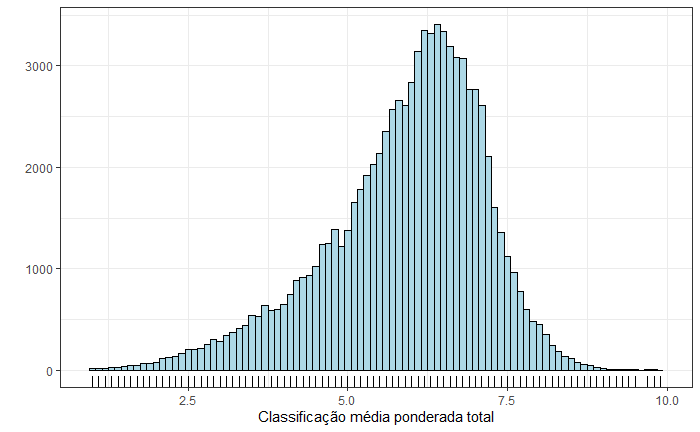

Na tabela abaixo podemos conferir que poucos filmes possuem uma classificação média maior/igual a 9.5 e que a maioria foram lançados nos últimos 10 anos.Talvez isso possa indicar que a qualidade dos filmes tiveram uma melhora nesse período.

| title | weighted_average_vote | year | duration |
| --- | --- | --- | --- |
| Suvarna Sundari | 9.9 | 2019 | 120 |
| Lejos de Casa pelicula Venezolana | 9.8 | 2020 | 87 |
| Jeeudo | 9.8 | 2020 | 150 |
| Ek | 9.8 | 2019 | 129 |
| Notuku Potu | 9.8 | 2017 | 121 |
| Meka Suri | 9.7 | 2020 | 86 |
| Hopeful Notes | 9.7 | 2010 | 94 |
| Vaarthakal Ithuvare | 9.7 | 2019 | 121 |
| The Moving on Phase | 9.5 | 2020 | 85 |
| Isha | 9.5 | 2020 | 118 |

Em relação a distribuição da duração dos filmes, ao observar o gráfico abaixo, percebemos que a grande maioria está dentro do que costuma-se ver que seria entre uma hora até cerca de duas horas e meia. Mas, existe uma cauda longa para a extremidade direita indicando filmes que ultrapassam 800 minutos, ou seja, são mais de 13 horas de filme.

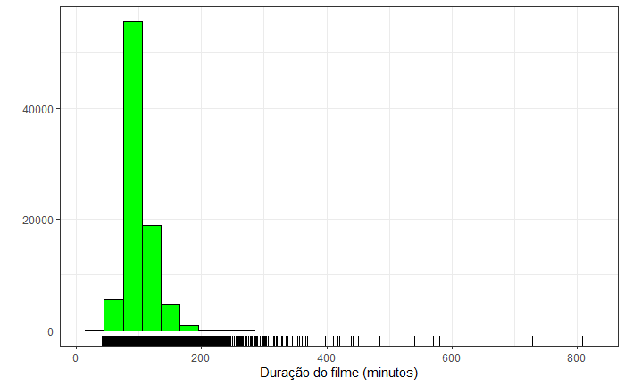

Na Tabela a seguir, podemos identificar os principais filmes com maior tempo de duração que fazem parte da extremidade direita do gráfico anterior, curioso que o maior é recente com lançamento em 2016.

| title | duration | weighted_average_vote | year |
| --- | --- | --- | --- |
| La flor | 808 | 7.7 | 2016 |
| Out 1, noli me tangere | 729 | 7.8 | 1971 |
| Khleb - imya sushchestvitelnoe | 580 | 5.8 | 1988 |
| Orbius | 570 | 9.3 | 2020 |
| Ebolusyon ng isang pamilyang Pilipino | 540 | 7.8 | 2004 |
| Heremias: Libro primo | 540 | 7.0 | 2006 |
| Kagadanan sa banwaan ning mga engkanto | 540 | 7.4 | 2007 |
| Hele sa hiwagang hapis | 485 | 7.4 | 2016 |
| Melancholia | 450 | 7.4 | 2008 |
| Hitler, un film dalla Germania | 442 | 7.6 | 1977 |

[output cut: 29 more lines]

Agora, vamos observar no gráfico abaixo, a distribuição dos dados em relação ao ano de lançamento dos filmes. Podemos perceber a evolução que houve na produção de filmes que foi crescendo de forma exponencial, principalmente a partir dos anos 2000.

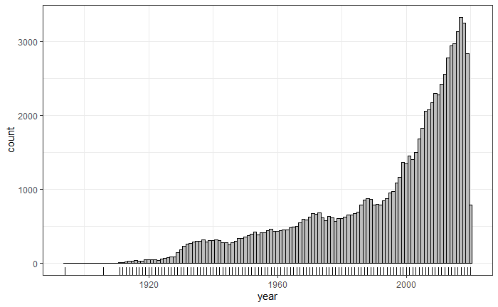

A tabela mostra os 10 filmes mais antigos da nossa base de dados, com ano de lançamento anterior a 1915.

| title | year | duration | weighted_average_vote |
| --- | --- | --- | --- |
| Miss Jerry | 1894 | 45 | 5.9 |
| The Story of the Kelly Gang | 1906 | 70 | 6.1 |
| Den sorte drøm | 1911 | 53 | 5.8 |
| L'Inferno | 1911 | 68 | 7.0 |
| Oborona Sevastopolya | 1911 | 100 | 6.0 |
| Pinocchio | 1911 | 50 | 5.7 |
| Karadjordje | 1911 | 80 | 6.2 |
| Cleopatra | 1912 | 100 | 5.2 |
| From the Manger to the Cross; or, Jesus of Nazareth | 1912 | 60 | 5.7 |
| Independenta Romaniei | 1912 | 120 | 6.7 |

[output cut: 37 more lines]

Agora, iremos verificar se existe alguma correlação entre a variável alvo, classificação média ponderada total, e alguma outra variável da base. A escolha será de forma empírica, com base no que os autores acreditam que possa haver uma possível correlação, por exemplo, iremos verificar as variáveis: total_votes, males_allages_avg_vote e non_us_voters_rating.

Na Figura , observamos o gráfico de dispersão entre a variável total de votos e a classificação média dos filmes. Podemos perceber que não existe uma correlação linear entre as variáveis, o coeficiente de correlação de Pearson foi de 0,18.

[figure not shown]

| corr_pearson |
| --- |
| 0.1865301 |

Já na Figura , podemos perceber que existe uma correlação positiva e forte entre as variáveis com um coeficiente de correlação de Pearson igual a 0,98.

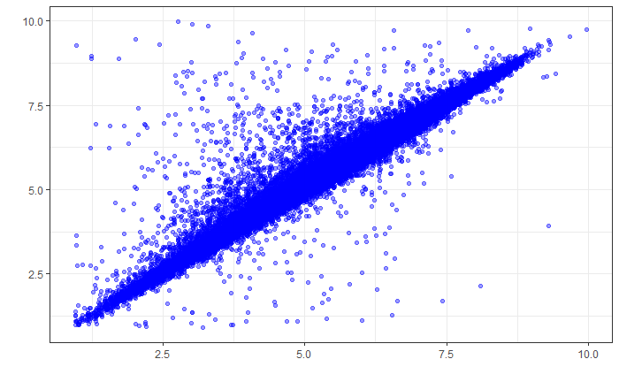

| corr_pearson |
| --- |
| 0.9856118 |

Nesse caso apresentado pela Figura , também é perceptível uma correlação considerável e positiva entre as variáveis analisadas com um coeficiente de correlação de Pearson igual a 0,96.

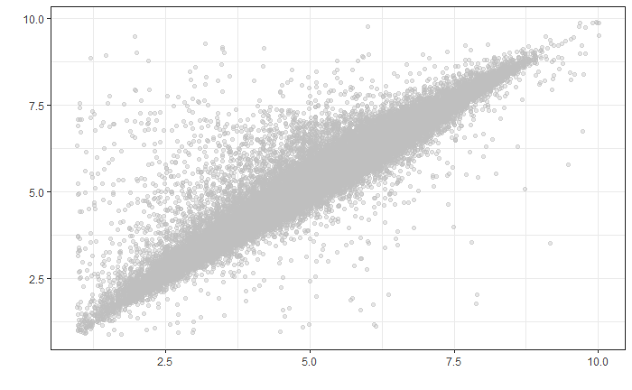

| corr_pearson |
| --- |
| 0.9694647 |

Provavelmente essas variáveis com uma correlação positiva e considerável terão uma influência maior nos modelos preditivos, verificaremos essa hipótese após a execução dos classificadores. A execução se encontra no notebook python também disponibilizado no projeto.